# Predicción de fuga de clientes en TELCO

# 1 Descripción del problema

Nuestra tarea en esta practica será predecir si un usuario se dará de baja en una empresa de telecomunicaciones. El conjunto de datos está sacado de una competición de [**Kaggle**](https://www.kaggle.com/blastchar/telco-customer-churn).

- **Churn** : Clientes que se fueron en el último mes (variable a predecir)
- **Servicios en los que cada cliente se ha registrado**: teléfono, varias líneas, Internet, seguridad en línea, respaldo en línea, protección de dispositivos, soporte técnico y transmisión de TV y películas.
- **Información de la cuenta del cliente**: permanencia del cliente, contrato, método de pago, facturación electrónica, cargos mensuales y cargos totales
- **Información demográfica sobre los clientes**: género, rango de edad, y si tienen socios y dependientes

# 2 Métrica de evaluación de nuestro problema (AUC)

La curva ROC es una medida de rendimiento para problemas de clasificación en función a varios umbrales. ROC es una curva de probabilidad y AUC representa el area bajo esa curva. Indica cuánto es capaz el modelo de distinguir entre clases. Cuanto más alto es el AUC, mejor es el modelo.

La curva ROC enfrenta 1- Specificity (FPR) frente a Sensitivity(TPR) para distintos puntos de corte.

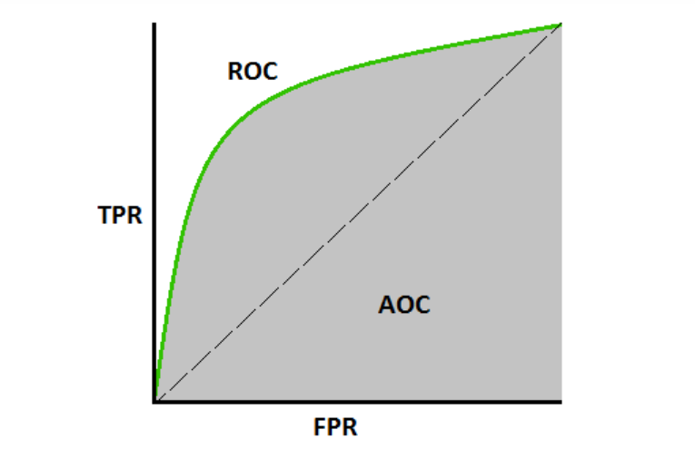

Curva AUC

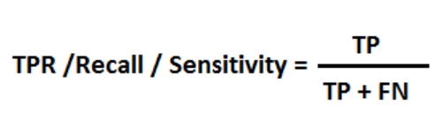

Sensitivity

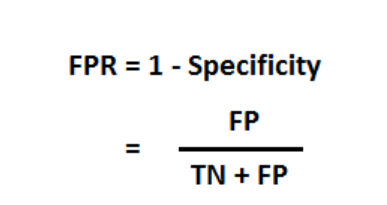

1-Specificity

# 3 Desarrollo de la práctica

## 3.1 Carga de librerías y datos

## 3.2 EDA

En este apartado trataremos de analizar las distintas variables que tenemos en nuestro dataset y encontrar distintos patrones que nos ayuden a modelizar en apartados posteriores.

Empezaremos visualizando un esquema de las distintas variables que tenemos en nuestro dataset:

```
Data Frame Summary
df
Dimensions: 7043 x 21
Duplicates: 0

--------------------------------------------------------------------------------------------------------------------------------------------
No   Variable            Stats / Values                   Freqs (% of Valid)     Graph                                  Valid      Missing
---- ------------------- -------------------------------- ---------------------- -------------------------------------- ---------- ---------
1    customerID          1. 0002-ORFBO                       1 ( 0.0%)                                                  7043       0
     [character]         2. 0003-MKNFE                       1 ( 0.0%)                                                  (100%)     (0%)
                         3. 0004-TLHLJ                       1 ( 0.0%)
                         4. 0011-IGKFF                       1 ( 0.0%)
                         5. 0013-EXCHZ                       1 ( 0.0%)
                         6. 0013-MHZWF                       1 ( 0.0%)
                         7. 0013-SMEOE                       1 ( 0.0%)
                         8. 0014-BMAQU                       1 ( 0.0%)
                         9. 0015-UOCOJ                       1 ( 0.0%)
                         10. 0016-QLJIS                      1 ( 0.0%)
                         [ 7033 others ]                  7033 (99.9%)           IIIIIIIIIIIIIIIIIII

2    gender              1. Female                        3488 (49.5%)           IIIIIIIII                              7043       0
     [character]         2. Male                          3555 (50.5%)           IIIIIIIIII                             (100%)     (0%)

3    SeniorCitizen       Min  : 0                         0 : 5901 (83.8%)       IIIIIIIIIIIIIIII                       7043       0
     [numeric]           Mean : 0.2                       1 : 1142 (16.2%)       III                                    (100%)     (0%)
                         Max  : 1

4    Partner             1. No                            3641 (51.7%)           IIIIIIIIII                             7043       0
     [character]         2. Yes                           3402 (48.3%)           IIIIIIIII                              (100%)     (0%)

5    Dependents          1. No                            4933 (70.0%)           IIIIIIIIIIIIII                         7043       0
     [character]         2. Yes                           2110 (30.0%)           IIIII                                  (100%)     (0%)

6    tenure              Mean (sd) : 32.4 (24.6)          73 distinct values     :                                      7043       0
     [numeric]           min < med < max:                                        :                 .                    (100%)     (0%)
                         0 < 29 < 72                                             : .               :
                         IQR (CV) : 46 (0.8)                                     : : : . . . . . . :
                                                                                 : : : : : : : : : :

7    PhoneService        1. No                             682 ( 9.7%)           I                                      7043       0
```

[output cut: 46 more lines]

```
19   MonthlyCharges      Mean (sd) : 64.8 (30.1)          1585 distinct values   :                                      7043       0
     [numeric]           min < med < max:                                        :                                      (100%)     (0%)
                         18.2 < 70.3 < 118.8                                     :         : : . .
                         IQR (CV) : 54.3 (0.5)                                   :     : . : : : :
                                                                                 : . : : : : : : : :

20   TotalCharges        Mean (sd) : 2283.3 (2266.8)      6530 distinct values   :                                      7032       11
     [numeric]           min < med < max:                                        :                                      (99.84%)   (0.16%)
                         18.8 < 1397.5 < 8684.8                                  : .
                         IQR (CV) : 3393.3 (1)                                   : :
                                                                                 : : : : : : . . .

21   Churn               1. No                            5174 (73.5%)           IIIIIIIIIIIIII                         7043       0
     [character]         2. Yes                           1869 (26.5%)           IIIII                                  (100%)     (0%)
--------------------------------------------------------------------------------------------------------------------------------------------
```

### 3.2.1 Transformación de datos

En primer lugar transformamos nuestras variables categóricas en factores y aquellas que tengan dos únicos niveles la transformamos en una variable binaria. Además, eliminamos la variable que identifica a cada cliente, ya que no nos sirve para modelizar.

```r
df <- df %>% mutate_if(is.character,as.factor)
df <- df %>% mutate(gender = ifelse(gender == "Male", 1, 0))
df <- df %>% mutate(Churn = ifelse(Churn == "Yes", 1,0))
df <- df %>% mutate(Partner = ifelse(Partner == "Yes", 1, 0))
df <- df %>% mutate(Dependents = ifelse(Dependents == "Yes", 1, 0))
df <- df %>% mutate(PhoneService = ifelse(PhoneService == "Yes", 1, 0))
df <- df %>% mutate(PaperlessBilling = ifelse(PaperlessBilling == "Yes", 1, 0))
df_backup_tenure <- df$tenure
df <- df %>% mutate(tenure = factor(cut(df$tenure, breaks = 6, labels = FALSE, ordered_result = TRUE)))



# variables que no se meten en la modelizacion
vars_drop <- c("customerID")
df <- df %>% select(-vars_drop)
```

### 3.2.2 Estudio de variables

En este apartado recogeremos particularidades importantes que hemos podido observar de algunas variables.

- Variable `Churn`

Vemos en primer lugar la tasa de fuga para nuestro problema:

```
[1] 0.2653699
```

Tenemos un 26.5369871% de fuga de clientes. Nuestra muestra no está del todo balanceada al 50%, pero tampoco es una tasa muy pequeña.

- Variable `TotalCharges`

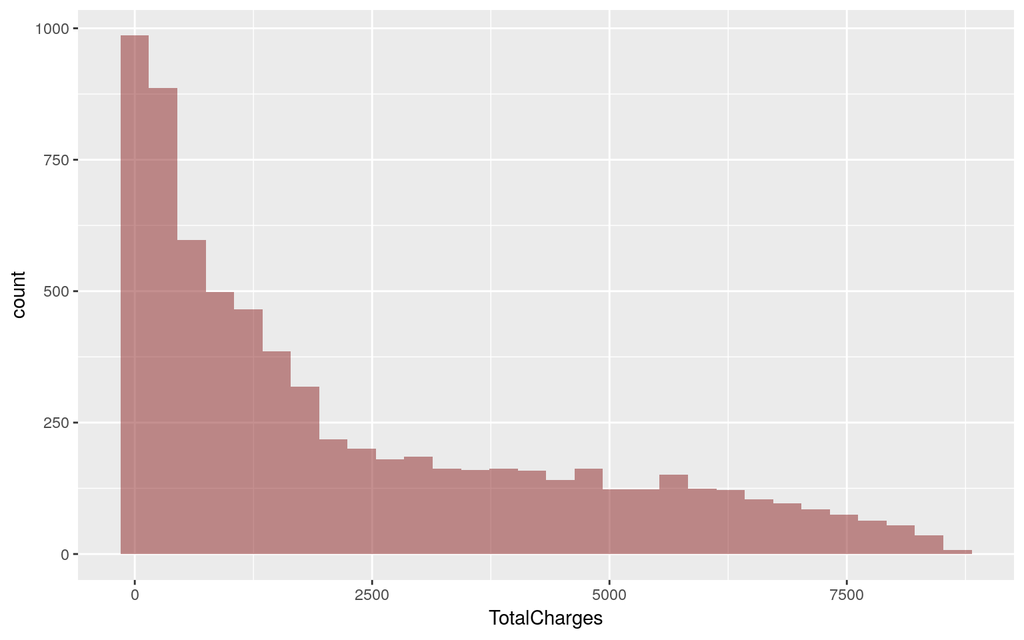

```r
df %>% ggplot(aes(x = TotalCharges)) +
  geom_histogram(alpha=0.5, fill = "brown4")
```

Como podemos apreciar, dicha variable tiene una cola grande a la derecha, por lo que estaría bien aplicarle la transformación logarítmica.

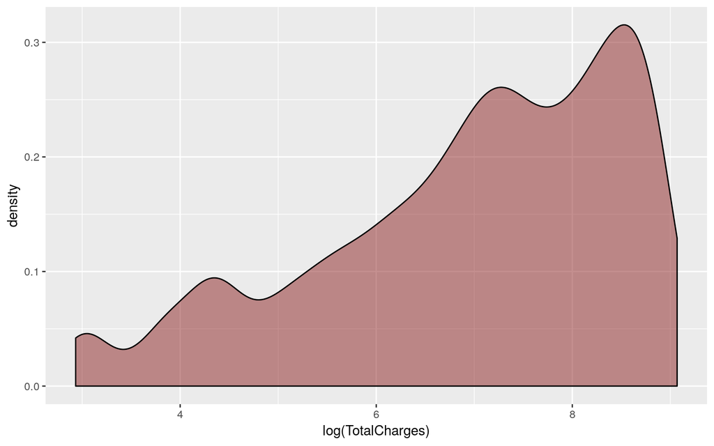

```r
df %>% ggplot(aes(x = log(TotalCharges))) +
  geom_density(alpha=0.5, fill = "brown4")
```

Reflejamos ahora la distribución de dicha variable discriminando por Fuga/No-Fuga:

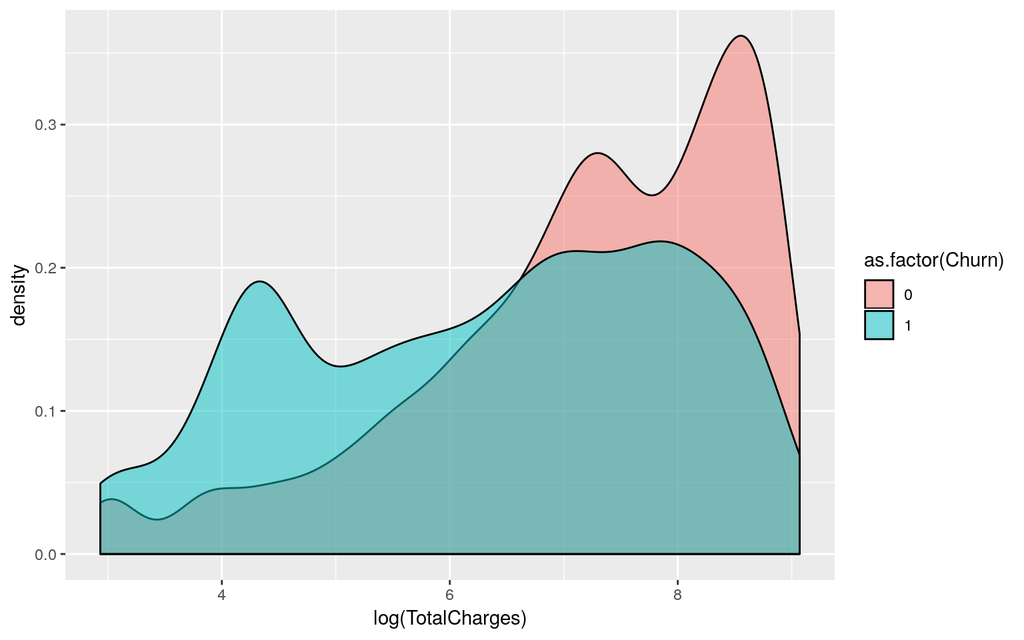

Apreciamos una distribución distinta para ambos grupos, lo que nos indica que a simple vista debería discriminar bien en nuestros modelos.

- Variables `InternetService`, `OnlineSecurity` y `TechSupport`

Nos calculamos la tasa de fuga por cada categoría que toman dichas variables:

```r
df %>% group_by(InternetService) %>% summarise(tasa_fuga = mean(Churn))
```

```
# A tibble: 3 x 2
  InternetService tasa_fuga
  <fct>               <dbl>
1 DSL                0.190
2 Fiber optic        0.419
3 No                 0.0740
```

```r
df %>% group_by(OnlineSecurity) %>% summarise(tasa_fuga = mean(Churn))
```

```
# A tibble: 3 x 2
  OnlineSecurity      tasa_fuga
  <fct>                   <dbl>
1 No                     0.418
2 No internet service    0.0740
3 Yes                    0.146
```

```r
df %>% group_by(TechSupport) %>% summarise(tasa_fuga = mean(Churn))
```

```
# A tibble: 3 x 2
  TechSupport         tasa_fuga
  <fct>                   <dbl>
1 No                     0.416
2 No internet service    0.0740
3 Yes                    0.152
```

- Variable `tenure`

Reflejamos la densidad de esta variable discriminando por Fuga/No-Fuga

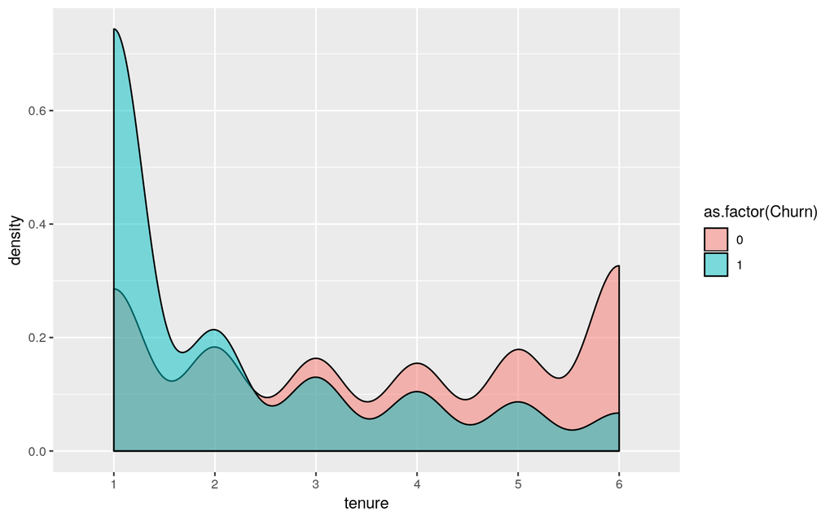

Aprenciamos dos distribuciones distintas para ambos grupos. Por lo que, a simple vista, dicha variable debería discriminar bien en nuestros modelos.

## 3.3 División en train y test

Dividimos nuestro conjunto de datos en Train y Test. El conjunto de datos de Train servirá para entrenar nuestros modelos y el conjunto de datos Test para dar una métrica final a nuestros modelos y poder decantarnos entre uno de ellos.

```r
set.seed(1234)
inTraining <- createDataPartition(df$Churn,
                                  p = 0.75, list = FALSE, times = 1)
df_training <- slice(df, inTraining)
df_testing <- slice(df, -inTraining)
```

## 3.4 Tratamiento de datos

### 3.4.1 Tratamiento Train

En este apartado se han imputado los valores missings de la variable `TotalCharges`por la media de la variable, se le ha aplicado el logaritmo, se ha creado las variables missings y se han eliminado las variables con una correlación mayor que un 90%

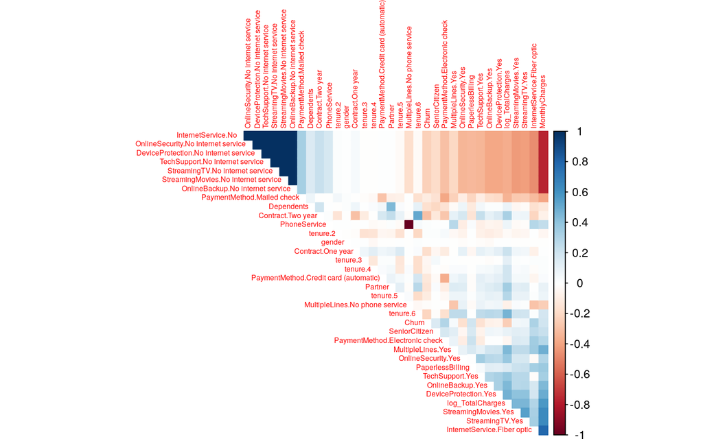

```r
# imputacion de NA's de la variable TotalCharges
mean_var <- mean(df_training$TotalCharges, na.rm = T)
df_train <- df_training %>% mutate(TotalCharges = ifelse(is.na(TotalCharges), mean_var, TotalCharges))

# transformacion de TotalCharges usando el logaritmo.
df_train <- df_train %>% mutate(log_TotalCharges = log(df_train$TotalCharges))
df_train <- df_train %>% select(-TotalCharges)

# variables dummies
dummy <- dummyVars(~ ., data = df_train, fullRank = TRUE)
df_train <- predict(dummy, df_train)

# variables correladas
M<-cor(df_train)
corrplot(M, diag = FALSE, order = "FPC",
         tl.pos = "td", tl.cex = 0.5, method = "color", type = "upper")
```

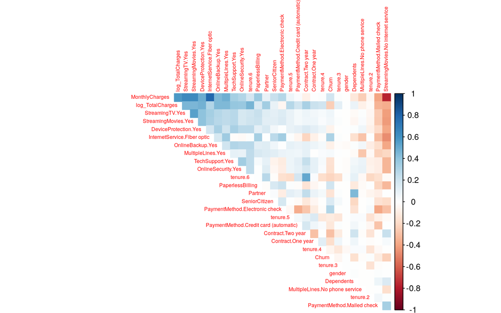

```r
# eliminamos variables con una correlacion mayor del 90%
M[upper.tri(M)] <- 0
diag(M) <- 0
M[!lower.tri(M)] <- 0

df_train <- as.data.frame(df_train[,!apply(M,2,function(x) any(abs(x) > 0.9))])

M<-cor(df_train)

corrplot(M, diag = FALSE, order = "FPC",
         tl.pos = "td", tl.cex = 0.5, method = "color", type = "upper")
```

```r
# cambiamos el nombre de las variables para que no nos aparezcan espacios en blanco
colnames(df_train) <- gsub(" ", "", colnames(df_train), fixed = TRUE)%>% str_replace("\\(.*\\)", "")
```

### 3.4.2 Tratamiento test

Realizamos al conjunto de datos de Test el mismo tratamiento que le hemos realizado al conjunto de datos de entrenamiento.

```r
# imputacion de NA's de la variable TotalCharges
df_test <- df_testing %>% mutate(TotalCharges = ifelse(is.na(TotalCharges), mean_var, TotalCharges))

# transformacion de TotalCharges usando el logaritmo.
df_test <- df_test %>% mutate(log_TotalCharges = log(df_test$TotalCharges))
df_test <- df_test %>% select(-TotalCharges)

# variables dummies
df_test <- predict(dummy, df_test)

# cambiamos el nombre de las variables
colnames(df_test) <- gsub(" ", "", colnames(df_test), fixed = TRUE) %>% str_replace("\\(.*\\)", "")

# variables correladas

# eliminamos las mismas variables correladas que en train
df_test <- as.data.frame(df_test[,names(df_train)])
```

## 3.5 Estrategias de modelización

En este apartado se describirán las distintas estrategias de modelización que se han llevado a cabo. Cada una de las estrategias serán comparadas con la métrica AUC.

### 3.5.1 Estrategia 1: GLM

En esta estrategia lanzaremos un modelo de regresión logística con todos los datos sin discriminar por ningún grupo. Aplicaremos LASSO como método de selección de variables.

- **Regresión lineal**

```r
# Lanzamos GLM
logr_vm <- glm(Churn ~ ., family = binomial, data = df_train)
summary(logr_vm)
```

```
Call:
glm(formula = Churn ~ ., family = binomial, data = df_train)

Deviance Residuals:
    Min       1Q   Median       3Q      Max
-2.2112  -0.6576  -0.2874   0.5694   3.1353

Coefficients:
                                  Estimate Std. Error z value Pr(>|z|)
(Intercept)                        3.68464    1.66105   2.218  0.02654 *
gender                             0.02033    0.07607   0.267  0.78932
SeniorCitizen                      0.24501    0.09796   2.501  0.01238 *
Partner                            0.11160    0.09150   1.220  0.22260
Dependents                        -0.14108    0.10409  -1.355  0.17528
tenure.2                          -0.03034    0.15325  -0.198  0.84305
tenure.3                          -0.11944    0.18957  -0.630  0.52865
tenure.4                           0.23381    0.21335   1.096  0.27312
tenure.5                           0.04205    0.23003   0.183  0.85494
tenure.6                          -0.18885    0.25762  -0.733  0.46353
MultipleLines.Nophoneservice      -0.20803    0.73732  -0.282  0.77783
MultipleLines.Yes                  0.55627    0.20125   2.764  0.00571 **
InternetService.Fiberoptic         1.75901    0.90379   1.946  0.05162 .
OnlineSecurity.Yes                -0.12942    0.20341  -0.636  0.52463
OnlineBackup.Yes                   0.03436    0.19998   0.172  0.86357
 [ reached getOption("max.print") -- omitted 13 rows ]
---
Signif. codes:  0 '***' 0.001 '**' 0.01 '*' 0.05 '.' 0.1 ' ' 1

(Dispersion parameter for binomial family taken to be 1)

    Null deviance: 6133.8  on 5282  degrees of freedom
Residual deviance: 4295.5  on 5255  degrees of freedom
AIC: 4351.5

Number of Fisher Scoring iterations: 6
```

- **Selección de variables con LASSO**

Utilizaremos validación cruzada para elegir el parámetro lambda que mejor se ajuste a nuestros datos. Elegiremos aquel que se diferencie en una unidad de error estandar con respecto al valor de lambda óptimo (el que maximiza el AUC)

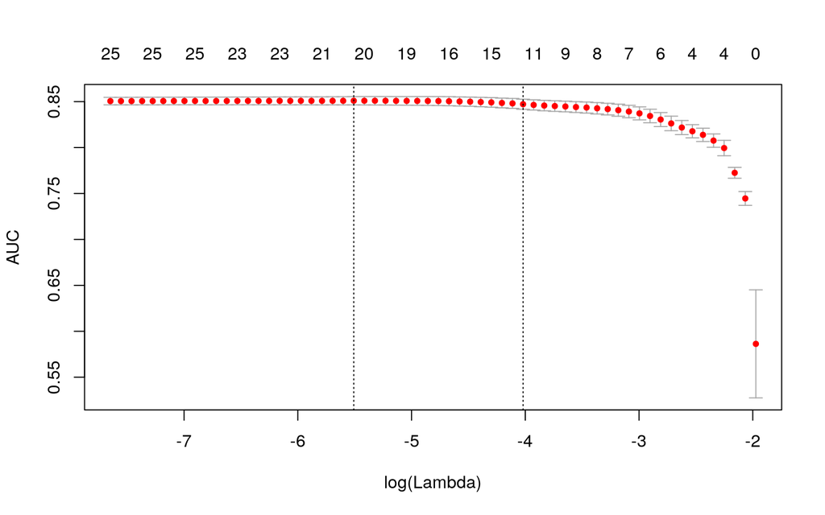

```r
x_train <- model.matrix(Churn~.,df_train)[,-1]
y_train <- as.factor(df_train$Churn)
x_test <- as.matrix(df_test %>% select(-Churn))
y_test <- as.factor(df_test$Churn)
cv.out <- cv.glmnet(x_train, y_train, alpha=1, nfolds=5, type.measure="auc", family="binomial")
plot(cv.out)
```

- Valor de lamba con el que entrenaremos:

```r
cv.out$lambda.1se
```

```
[1] 0.0179619
```

- Coeficientes del Lasso:

```r
tmp_coeffs <- coef(cv.out, s = "lambda.1se")

tmp_coeffs
```

```
28 x 1 sparse Matrix of class "dgCMatrix"
                                            1
(Intercept)                        1.36227830
gender                             .
SeniorCitizen                      0.14135096
Partner                            .
Dependents                         .
tenure.2                           .
tenure.3                           .
tenure.4                           .
tenure.5                           .
tenure.6                           .
MultipleLines.Nophoneservice       .
MultipleLines.Yes                  0.02159438
InternetService.Fiberoptic         1.11202365
OnlineSecurity.Yes                -0.10616275
OnlineBackup.Yes                   .
DeviceProtection.Yes               .
TechSupport.Yes                   -0.01680415
StreamingTV.Yes                    0.07642069
StreamingMovies.Nointernetservice -0.92546994
StreamingMovies.Yes                0.03247201
Contract.Oneyear                  -0.45558219
Contract.Twoyear                  -0.95571145
PaperlessBilling                   0.26602183
PaymentMethod.Creditcard           .
PaymentMethod.Electroniccheck      0.34451625
PaymentMethod.Mailedcheck          .
MonthlyCharges                     .
log_TotalCharges                  -0.42680977
```

- **Predicción en Test**

```r
lasso.pred=predict(cv.out, newx = x_test, type="response")
```

- **Curva ROC y métrica AUC en Test**

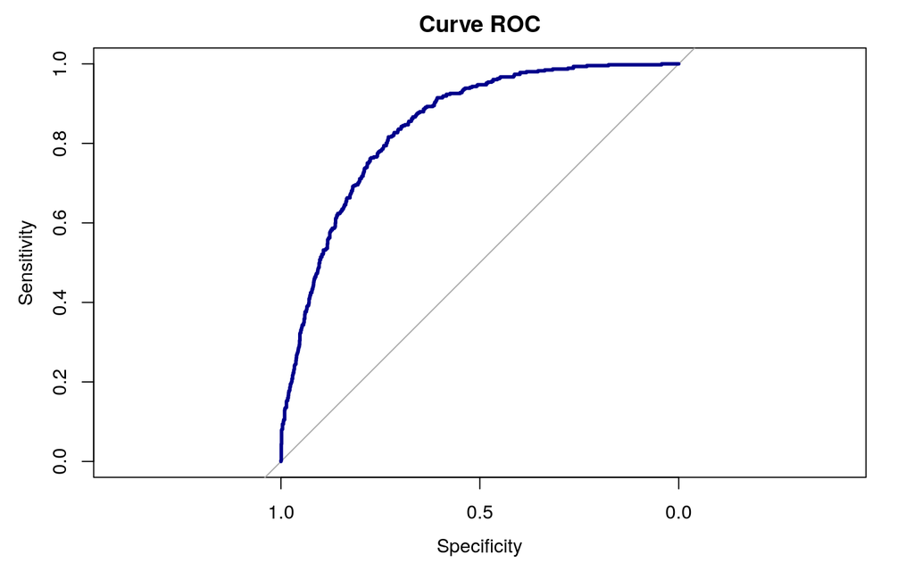

```
          auc
glm 0.8448858
```

- **Matriz de confusión**

```
Confusion Matrix and Statistics


lasso_class    0    1
          0 1208  266
          1   95  191

               Accuracy : 0.7949
                 95% CI : (0.7753, 0.8135)
    No Information Rate : 0.7403
    P-Value [Acc > NIR] : 5.202e-08

                  Kappa : 0.3927
 Mcnemar's Test P-Value : < 2.2e-16

            Sensitivity : 0.4179
            Specificity : 0.9271
         Pos Pred Value : 0.6678
         Neg Pred Value : 0.8195
             Prevalence : 0.2597
         Detection Rate : 0.1085
   Detection Prevalence : 0.1625
      Balanced Accuracy : 0.6725

       'Positive' Class : 1
```

### 3.5.2 Estrategia 2: GLM 2

En esta estrategia lanzaremos un modelo de regresión discriminando por los clientes que tienen internet frente a los que no. Para ello nos crearemos una variable binaria `has_internet`que nos servirá para discriminar dos rectas distintas de regresión en nuestro modelo.

Como en la estrategia anterior, aplicaremos LASSO como método de selección de variables.

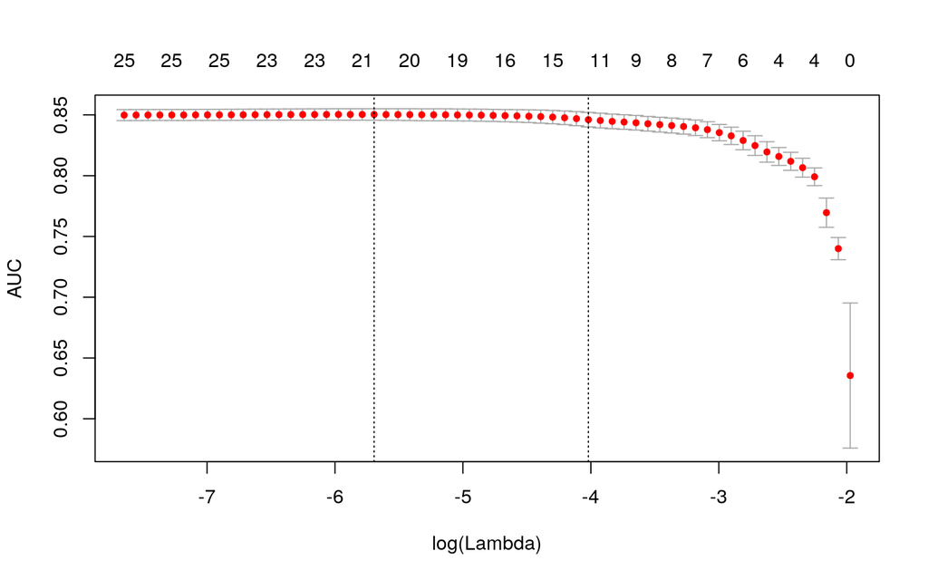

```r
x_train <- model.matrix(Churn~.,df_train)[,-1]
y_train <- as.factor(df_train$Churn)
x_test <- as.matrix(df_test %>% select(-Churn))
cv.out <- cv.glmnet(x_train,y_train,alpha=1, nfolds=5, type.measure="auc", family="binomial")
plot(cv.out)
```

El valor de lambda que usaremos es el valor que dista una unidad de error estándar del lambda que maximiza el auc.

```r
cv.out$lambda.1se # valor de lamba que se utilizará a la hora de predecir (en el predict por defecto está ese valor)
```

```
[1] 0.0179619
```

A continuación se muestran los coeficientes del LASSO para el valor de lambda que hemos seleccionado.

```r
tmp_coeffs <- coef(cv.out, s = "lambda.1se") # coeficientes del lasso para el valor de lamba que hemos seleccionado

tmp_coeffs
```

```
28 x 1 sparse Matrix of class "dgCMatrix"
                                        1
(Intercept)                    0.43675156
gender                         .
SeniorCitizen                  0.14136022
Partner                        .
Dependents                     .
tenure.2                       .
tenure.3                       .
tenure.4                       .
tenure.5                       .
tenure.6                       .
MultipleLines.Nophoneservice   .
MultipleLines.Yes              0.02161234
InternetService.Fiberoptic     1.11194568
OnlineSecurity.Yes            -0.10619262
OnlineBackup.Yes               .
DeviceProtection.Yes           .
TechSupport.Yes               -0.01682165
StreamingTV.Yes                0.07640514
StreamingMovies.Yes            0.03251359
Contract.Oneyear              -0.45565257
Contract.Twoyear              -0.95583503
PaperlessBilling               0.26605000
PaymentMethod.Creditcard       .
PaymentMethod.Electroniccheck  0.34453922
PaymentMethod.Mailedcheck      .
MonthlyCharges                 .
has_internet                   0.92538377
log_TotalCharges              -0.42678561
```

- **Predicción en Test**

Realizamos validación con los datos del test sobre el modelo de regresión logística binomial que hemos entrenado en el apartado anterior sobre los datos de entrenamiento.

- **Curva ROC y métrica AUC en Test**

Representamos la curva ROC y calculamos la métrica AUC a partir de los resultados de test.

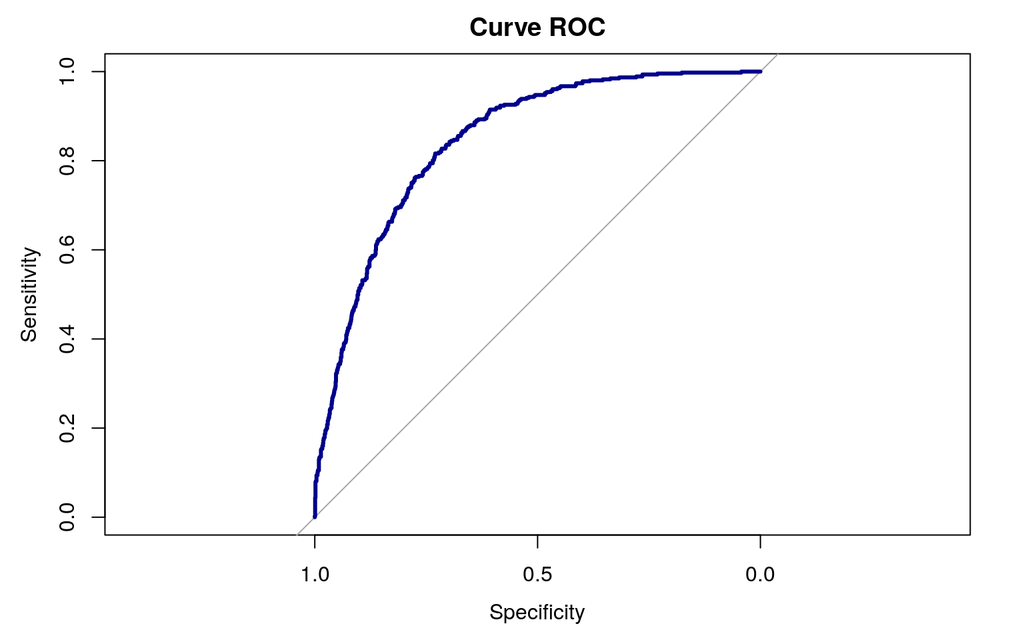

```r
roc_glm2 = roc(df_test$Churn, lasso.pred)
plot(roc_glm2,
     col="darkblue", lwd=3, main="Curve ROC")
```

```r
auc_df["glm2","auc"] <- ModelMetrics::auc(df_test$Churn,lasso.pred)
auc_df
```

```
           auc
glm  0.8448858
glm2 0.8448858
```

Los resultados obtenidos con esté método son similares al método utilizado en la estrategia anterior.

- **Matriz de confusión**

```
Confusion Matrix and Statistics


lasso_class    0    1
          0 1208  266
          1   95  191

               Accuracy : 0.7949
                 95% CI : (0.7753, 0.8135)
    No Information Rate : 0.7403
    P-Value [Acc > NIR] : 5.202e-08

                  Kappa : 0.3927
 Mcnemar's Test P-Value : < 2.2e-16

            Sensitivity : 0.4179
            Specificity : 0.9271
         Pos Pred Value : 0.6678
         Neg Pred Value : 0.8195
             Prevalence : 0.2597
         Detection Rate : 0.1085
   Detection Prevalence : 0.1625
      Balanced Accuracy : 0.6725

       'Positive' Class : 1
```

### 3.5.3 Estrategia 3: Clustering

En esta estrategia realizaremos clustering k-means con las varibles del Lasso establecidas anteriormente y lanzaremos un modelo de regresión por cada grupo obtenido.

Vamos a estandarizar las variables para mejorar el resultado del clustering.

```r
# nos quedamos con las variables del Lasso y normalizamos
important_variables <- names(tmp_coeffs[,1][tmp_coeffs[,1] != 0])

df_train_cluster <- df_train %>% select(setdiff(important_variables, "(Intercept)" ))

scaled.df_train <- scale(df_train_cluster)
```

Es necesario establecer el número de clusters adecuado para nuestros datos. Para ello, utilizamos la libreria factoextra, que contiene varios métodos para este cometido envueltos en funciones simples.

**Método del “codo”:**

La idea de este método consiste en ejecutar k-means en los datos para un rango k de valores (en nuestro caso de 1 a 10), y para cada valor de k calcular la suma de los errores cuadráticos intra cluster.

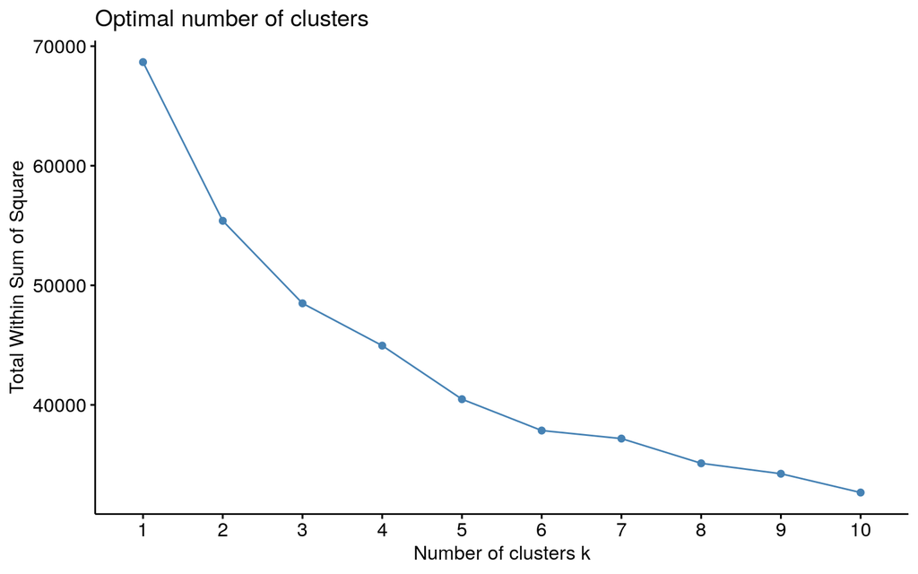

```r
fviz_nbclust(scaled.df_train, kmeans, method = "wss")
```

Aunque no se observa un resultado claro, parece que un valor entre 3 y 6 clusters podría ser razonable.

**Método de la silueta:**

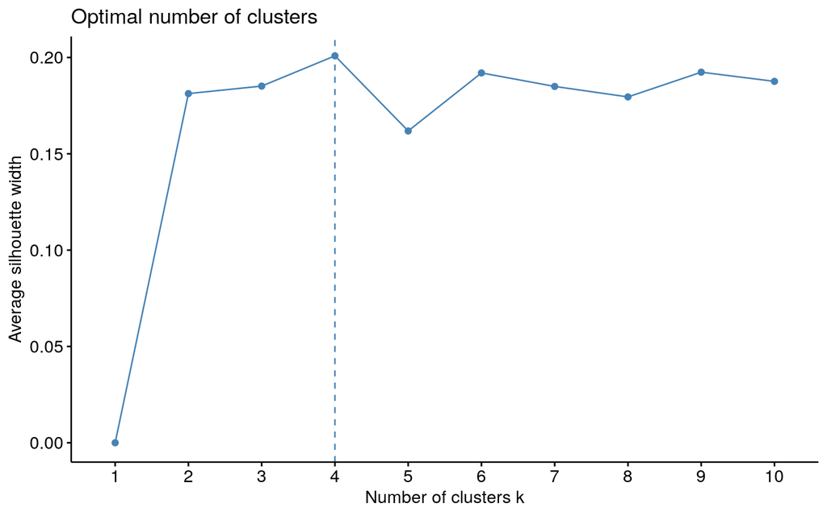

```r
fviz_nbclust(scaled.df_train, kmeans, method = "silhouette")
```

Tal y como indica el método de la silueta, escogemos 4 clusters.

- **Clustering con K-means**

Aplicamos k-means para determinar los 4 grupos:

```r
clusters <- kmeans(x = scaled.df_train, centers = 4, nstart = 25)
df_train <- df_train %>% mutate(cluster = as.factor(clusters$cluster))
```

Convertimos la variable “cluster” en dummies de forma que obtenemos 3 nuevas variables indicando cada una la pertenencia o no del dato al cluster en cuestión. Esto nos permitirá lanzar un glm para cada cluster para que después Lasso nos indique cuales de estas nuevas variables son significativas.

```r
dummy <- dummyVars(~ ., data = df_train, fullRank = TRUE)
df_train <- as.data.frame(predict(dummy, df_train))
knitr::kable(head(df_train))
```

| gender | SeniorCitizen | Partner | Dependents | tenure.2 | tenure.3 | tenure.4 | tenure.5 | tenure.6 | MultipleLines.Nophoneservice | MultipleLines.Yes | InternetService.Fiberoptic | OnlineSecurity.Yes | OnlineBackup.Yes | DeviceProtection.Yes | TechSupport.Yes | StreamingTV.Yes | StreamingMovies.Yes | Contract.Oneyear | Contract.Twoyear | PaperlessBilling | PaymentMethod.Creditcard | PaymentMethod.Electroniccheck | PaymentMethod.Mailedcheck | MonthlyCharges | Churn | has_internet | log_TotalCharges | cluster.2 | cluster.3 | … |
| --- | --- | --- | --- | --- | --- | --- | --- | --- | --- | --- | --- | --- | --- | --- | --- | --- | --- | --- | --- | --- | --- | --- | --- | --- | --- | --- | --- | --- | --- | --- |
| 1 | 0 | 0 | 0 | 0 | 0 | 0 | 0 | 0 | 0 | 0 | 0 | 1 | 1 | 0 | 0 | 0 | 0 | 0 | 0 | 1 | 0 | 0 | 1 | 53.85 | 1 | 1 | 4.683519 | 0 | 0 | … |
| 1 | 0 | 0 | 0 | 0 | 0 | 1 | 0 | 0 | 1 | 0 | 0 | 1 | 0 | 1 | 1 | 0 | 0 | 1 | 0 | 0 | 0 | 0 | 0 | 42.30 | 0 | 1 | 7.517928 | 1 | 0 | … |
| 0 | 0 | 0 | 0 | 0 | 0 | 0 | 0 | 0 | 0 | 0 | 1 | 0 | 0 | 0 | 0 | 0 | 0 | 0 | 0 | 1 | 0 | 1 | 0 | 70.70 | 1 | 1 | 5.021575 | 0 | 0 | … |
| 0 | 0 | 0 | 0 | 0 | 0 | 0 | 0 | 0 | 0 | 1 | 1 | 0 | 0 | 1 | 0 | 1 | 1 | 0 | 0 | 1 | 0 | 1 | 0 | 99.65 | 1 | 1 | 6.709914 | 0 | 0 | … |
| 1 | 0 | 0 | 1 | 1 | 0 | 0 | 0 | 0 | 0 | 1 | 1 | 0 | 1 | 0 | 0 | 1 | 0 | 0 | 0 | 1 | 1 | 0 | 0 | 89.10 | 0 | 1 | 7.575277 | 0 | 0 | … |
| 0 | 0 | 0 | 0 | 0 | 0 | 0 | 0 | 0 | 1 | 0 | 0 | 1 | 0 | 0 | 0 | 0 | 0 | 0 | 0 | 0 | 0 | 0 | 1 | 29.75 | 0 | 1 | 5.710096 | 0 | 0 | … |

- **Lanzamos LASSO:**

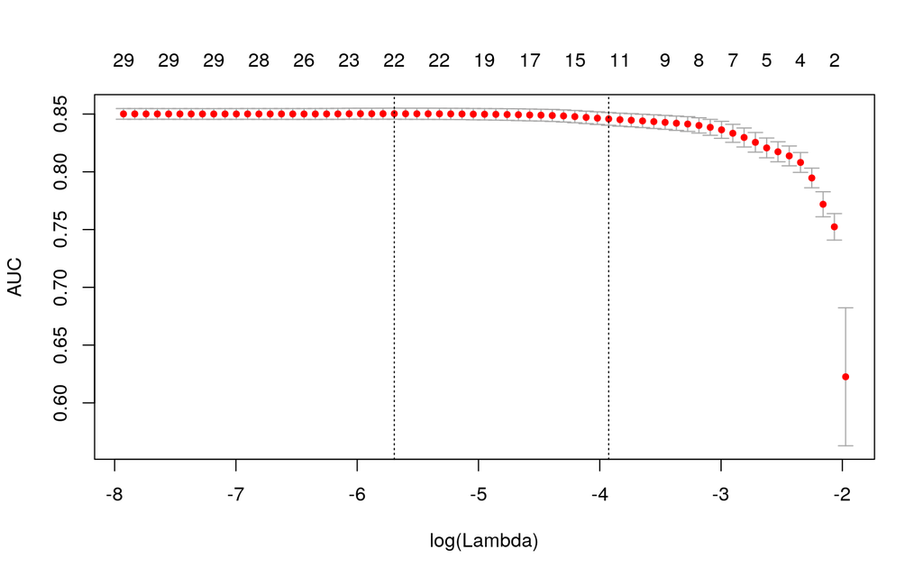

```r
x_train <- model.matrix(Churn~.,df_train)[,-1]
y_train <- as.factor(df_train$Churn)
cv.out <- cv.glmnet(x_train,y_train,alpha=1, nfolds=5, type.measure="auc", family="binomial")
plot(cv.out)
```

```r
cv.out$lambda.1se
```

```
[1] 0.01971317
```

```r
tmp_coeffs <- coef(cv.out, s = "lambda.1se")

tmp_coeffs
```

```
31 x 1 sparse Matrix of class "dgCMatrix"
                                         1
(Intercept)                    1.117655819
gender                         .
SeniorCitizen                  0.128837692
Partner                        .
Dependents                     .
tenure.2                       .
tenure.3                       .
tenure.4                       .
tenure.5                       .
tenure.6                       .
MultipleLines.Nophoneservice   .
MultipleLines.Yes              .
InternetService.Fiberoptic     1.109477064
OnlineSecurity.Yes            -0.092789919
OnlineBackup.Yes               .
DeviceProtection.Yes           .
TechSupport.Yes                .
StreamingTV.Yes                0.051255376
StreamingMovies.Yes            0.008502104
Contract.Oneyear              -0.436199878
Contract.Twoyear              -0.922043809
PaperlessBilling               0.253948321
PaymentMethod.Creditcard       .
PaymentMethod.Electroniccheck  0.348722701
PaymentMethod.Mailedcheck      .
MonthlyCharges                 .
has_internet                   0.157182491
log_TotalCharges              -0.410706029
cluster.2                      .
cluster.3                     -0.726090757
cluster.4                      .
```

Observamos que las variables correspondientes a los clusters 2 y 4 no resultan ser significativas. Esto nos indica que pertenecer o no a dichos grupos no es relevante para nuestra predicción.

- **Predicción en Test**

Utilizamos la distancia euclidea para asignar a cada observación de test el cluster al que pertenece.

```r
df_test_cluster <- df_test %>% select(setdiff(important_variables, "(Intercept)" ))
scaled.df_test <- scale(df_test_cluster)

cluster_test <- apply(scaled.df_test, 1, function(x){
  distances <- apply(clusters$centers, 1, function(y){
    return(dist(rbind(x,y)))
  })

  cluster_min <- as.numeric(which.min(distances))
  return(cluster_min)

})

df_test <- df_test %>% mutate(cluster = as.character(cluster_test))
```

Hacemos variables dummies y predecimos:

```r
df_test <- as.data.frame(predict(dummy, df_test))
x_test <- as.matrix(df_test %>% dplyr::select(-Churn))

lasso.pred=predict(cv.out,newx = x_test, type="response")
```

- **Curva ROC y métrica AUC en Test**

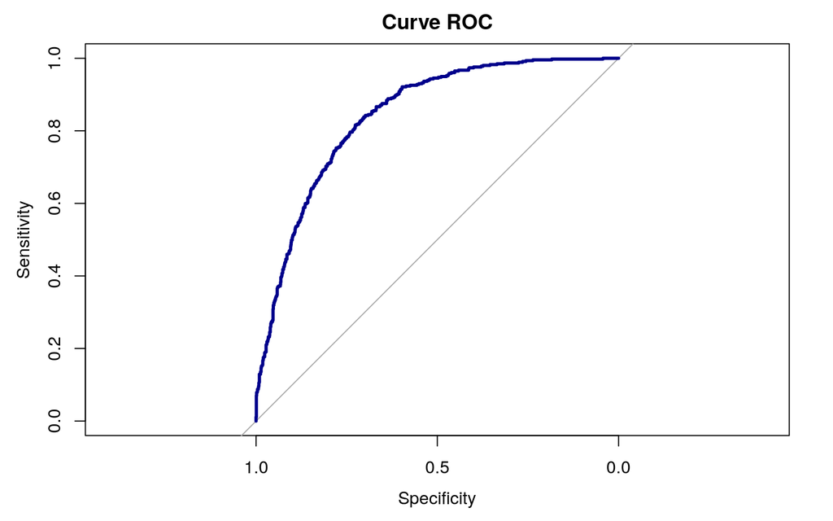

```r
roc_clust = roc(df_test$Churn, lasso.pred)
plot(roc_clust,
     col="darkblue", lwd=3, main="Curve ROC")
```

```r
auc_df["clust","auc"] <- ModelMetrics::auc(df_test$Churn,lasso.pred)
auc_df
```

```
            auc
glm   0.8448858
glm2  0.8448858
clust 0.8435591
```

- **Matriz de confusión**

```
Confusion Matrix and Statistics


lasso_class    0    1
          0 1211  275
          1   92  182

               Accuracy : 0.7915
                 95% CI : (0.7717, 0.8102)
    No Information Rate : 0.7403
    P-Value [Acc > NIR] : 3.24e-07

                  Kappa : 0.3766
 Mcnemar's Test P-Value : < 2.2e-16

            Sensitivity : 0.3982
            Specificity : 0.9294
         Pos Pred Value : 0.6642
         Neg Pred Value : 0.8149
             Prevalence : 0.2597
         Detection Rate : 0.1034
   Detection Prevalence : 0.1557
      Balanced Accuracy : 0.6638

       'Positive' Class : 1
```

Se observa que no hemos obtenido una mejora apreciable de hacer clustering, ya que los resultados son muy similares.

### 3.5.4 Estrategia 4: KNN

Como una cuarta estrategia usaremos el algoritmo de k-Nearest Neighbors. Es un algoritmo de aprendizaje **supervisado** en el cual partimos de un set de observaciones *(x, y)* etiquetadas y queremos capturar la relación entre *x* e *y*.

Originalmente KNN es un algoritmo de clasificación **no paramétrico** y **basado en instancias**. Esto último en particular significa que el algoritmo no aprende o entrena un modelo exactamente. En cambio, memoriza las instancias que le pases y las usa directamente como conocimiento para la fase de predicción.

En nuestro caso usaremos los datos del set de train para seleccionar un *k* óptimo en base a la métrica seleccionada y el de test para validar el modelo. Por último, compararemos las 4 estrategias usadas en base a la misma métrica para decidir un único modelo.

Seleccionamos solo las variables que ha devuelto el algoritmo de selección LASSO.

```r
names_cols <- names(tmp_coeffs[,1][tmp_coeffs[,1] != 0])
names_cols <- c(setdiff(names_cols, "(Intercept)" ), "Churn")
df_train <- select(df_train, names_cols)
df_test <- select(df_test, names_cols)
```

#### 3.5.4.1 Selección de k y entrenamiento de modelo

Vamos a buscar el mejor k para obtener las mejores métricas que definan el modelo. Para ello ejecutaremos el modelo varias veces calculando *auc* en cada iteración. El rango de k donde buscamos será entre 1 y 15 y la decisión la tomaremos basándonos en la métrica *auc*. Sin embargo, calcularemos también las métricas de *accuracy*, *precision* y *recall*.

```r
long = 15
accuracy = rep(0,long)
f1score = rep(0,long)
recall = rep(0,long)
precision = rep(0,long)
auc_metric = rep(0,long)
for (i in 1:long)
{
 prediccion_knn_cv =knn.cv(df_train %>% dplyr::select(-Churn),
                           k=i, cl=df_train$Churn)
 accuracy[i] = sum(prediccion_knn_cv == df_train$Churn) /nrow(df_train)
 recall[i] = sum(prediccion_knn_cv == df_train$Churn & df_train$Churn == 1) / sum(df_train$Churn == 1)
 precision[i] = sum(prediccion_knn_cv == df_train$Churn & prediccion_knn_cv == 1) / sum(prediccion_knn_cv == 1)
 auc_metric[i] = ModelMetrics::auc(df_train$Churn,prediccion_knn_cv)
}
resultados_knn = as.data.frame(cbind(accuracy,f1score,precision,recall,auc_metric))
resultados_knn = resultados_knn %>% mutate(index=as.factor(seq(1:long)))
```

```r
optimal_k_auc = which.max(resultados_knn$auc_metric)
optimal_k_auc
```

```
[1] 12
```

- **Predicción en test**

```r
knn_test = knn(df_train %>% dplyr::select(-Churn), df_test %>% dplyr::select(-Churn), k=optimal_k_auc, cl=df_train$Churn, prob = TRUE)
```

El AUC que obtenemos es el siguiente:

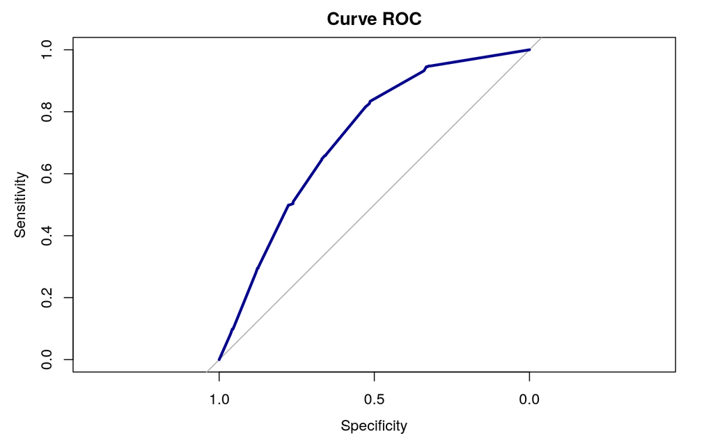

```r
roc_knn = roc(df_test$Churn,attr(knn_test, "prob"))
plot(roc_knn,
     col="darkblue", lwd=3, main="Curve ROC")
```

```r
auc_df["knn", "auc"] = ModelMetrics::auc(df_test$Churn, knn_test)
auc_df
```

```
            auc
glm   0.8448858
glm2  0.8448858
clust 0.8435591
knn   0.7029738
```

- **Matriz de confusión**

```
Confusion Matrix and Statistics


knn_test    0    1
       0 1122  208
       1  181  249

               Accuracy : 0.779
                 95% CI : (0.7589, 0.7982)
    No Information Rate : 0.7403
    P-Value [Acc > NIR] : 9.619e-05

                  Kappa : 0.4139
 Mcnemar's Test P-Value : 0.1874

            Sensitivity : 0.5449
            Specificity : 0.8611
         Pos Pred Value : 0.5791
         Neg Pred Value : 0.8436
             Prevalence : 0.2597
         Detection Rate : 0.1415
   Detection Prevalence : 0.2443
      Balanced Accuracy : 0.7030

       'Positive' Class : 1
```

### 3.5.5 Estrategia 5: SVM

Otra estrategia que nos queda por probar es Support Vector Machines (SVM). Una SVM construye un hiperplano o conjunto de hiperplanos en un espacio de dimensionalidad muy alta (o incluso infinita) que puede ser utilizado en problemas de clasificación o regresión. Una buena separación entre las clases permitirá una clasificación correcta.

```r
library(e1071)

model <- svm(y = y_train, x = x_train, kernel = "linear", cost = 10, type = "C-classification", scale = FALSE, probability = TRUE)
summary(model)
```

```
Call:
svm.default(x = x_train, y = y_train, scale = FALSE, type = "C-classification",
    kernel = "linear", cost = 10, probability = TRUE)


Parameters:
   SVM-Type:  C-classification
 SVM-Kernel:  linear
       cost:  10

Number of Support Vectors:  2384

 ( 1189 1195 )


Number of Classes:  2

Levels:
 0 1
```

- Predicción en test

```r
testprediction <- predict(model, x_test, probability = TRUE)
pred_svm <- attr(testprediction, "prob")[,1]
```

El AUC que obtenemos es el siguiente:

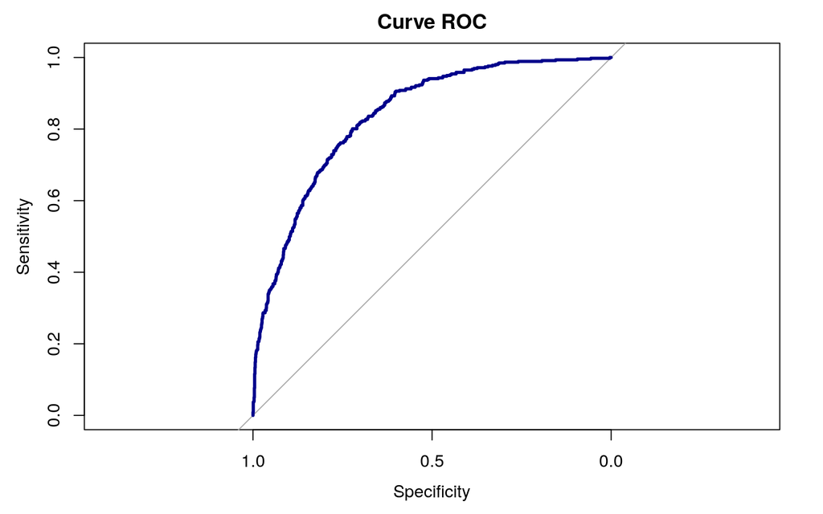

```r
roc_svm = roc(df_test$Churn,pred_svm)
plot(roc_svm,
     col="darkblue", lwd=3, main="Curve ROC")
```

```r
auc_df["svm", "auc"] = ModelMetrics::auc(df_test$Churn, pred_svm)
auc_df
```

```
            auc
glm   0.8448858
glm2  0.8448858
clust 0.8435591
knn   0.7029738
svm   0.8379476
```

### 3.5.6 Estrategia 6: Árboles de decisión

Vamos a entrenar ahora un árbol de decisión

```r
library(rpart)
library(rattle)

df_train_factor <- df_train %>% mutate(Churn = as.factor(Churn))
levels(df_train_factor$Churn) <- c("class_0", "class_1")
df_test_factor <- df_test %>% mutate(Churn = as.factor(Churn))
levels(df_test_factor$Churn) <- c("class_0", "class_1")

# TRAIN
churn.dt = rpart(Churn~., data=df_train_factor, control = rpart.control(cp = 0.001, maxdepth = 10, minbucket = 10))

# Predict
dt_pred.train=predict(churn.dt, df_train_factor)
dt_pred.test=predict(churn.dt, df_test_factor, type="prob")[,"class_1"]

roc_dt = roc(df_test_factor$Churn, as.vector(dt_pred.test))
auc_df["tree", "auc"] = ModelMetrics::auc(df_test_factor$Churn, as.vector(dt_pred.test))
```

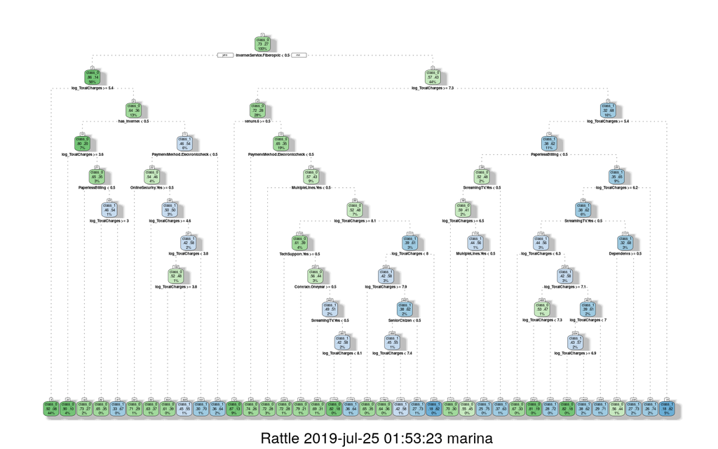

```
            auc
glm   0.8448858
glm2  0.8448858
clust 0.8435591
knn   0.7029738
svm   0.8379476
tree  0.7872482
```

El auc obtenido no supone una mejoría con respecto a lo obtenido anteriormente.

```
Confusion Matrix and Statistics


       0    1
  0 1130  212
  1  173  245

               Accuracy : 0.7812
                 95% CI : (0.7612, 0.8004)
    No Information Rate : 0.7403
    P-Value [Acc > NIR] : 3.836e-05

                  Kappa : 0.4148
 Mcnemar's Test P-Value : 0.05279

            Sensitivity : 0.5361
            Specificity : 0.8672
         Pos Pred Value : 0.5861
         Neg Pred Value : 0.8420
             Prevalence : 0.2597
         Detection Rate : 0.1392
   Detection Prevalence : 0.2375
      Balanced Accuracy : 0.7017

       'Positive' Class : 1
```

### 3.5.7 Estrategia 7: Random Forest

El algoritmo Random Forest tiene una cantidad de metaparámetros a definir. Para elegir la combinación de parámetros optima lanzaremos un Grid Search con validacion cruzada. Los parametros que queremos optimizar son el numero de arboles y el número de variabes seleccionadas aleatoriamente de cada arbol. Lo implementaremos con la libreria *Caret* y *RandomForest*:

```r
library(randomForest)
library(mlbench)
library(caret)

customRF <- list(type = "Classification",
                 library = "randomForest",
                 loop = NULL)

customRF$parameters <- data.frame(parameter = c("mtry", "ntree"),
                                  class = rep("numeric", 2),
                                  label = c("mtry", "ntree"))

customRF$grid <- function(x, y, len = NULL, search = "grid") {}

customRF$fit <- function(x, y, wts, param, lev, last, weights, classProbs) {
  randomForest(x, y,
               mtry = param$mtry,
               ntree=param$ntree)
}

#Predict label
customRF$predict <- function(modelFit, newdata, preProc = NULL, submodels = NULL)
   predict(modelFit, newdata)

#Predict prob
customRF$prob <- function(modelFit, newdata, preProc = NULL, submodels = NULL)
   predict(modelFit, newdata, type = "prob")

customRF$sort <- function(x) x[order(x[,1]),]
customRF$levels <- function(x) x$classes
```

```r
control <- trainControl(method="cv",
                        number=5,
                        allowParallel = TRUE,
                        #verboseIter = TRUE,
                        classProbs = TRUE)

tunegrid <- expand.grid(.mtry=c(1:10),.ntree=c(100,500))

custom <- caret::train(Churn~., data=df_train_factor,
                method=customRF,
                metric='ROC',
                tuneGrid=tunegrid,
                trControl=control)

summary(custom)
```

```
                Length Class      Mode
call                5  -none-     call
type                1  -none-     character
predicted        5283  factor     numeric
err.rate          300  -none-     numeric
confusion           6  -none-     numeric
votes           10566  matrix     numeric
oob.times        5283  -none-     numeric
classes             2  -none-     character
importance         15  -none-     numeric
importanceSD        0  -none-     NULL
localImportance     0  -none-     NULL
proximity           0  -none-     NULL
ntree               1  -none-     numeric
mtry                1  -none-     numeric
forest             14  -none-     list
y                5283  factor     numeric
test                0  -none-     NULL
inbag               0  -none-     NULL
xNames             15  -none-     character
problemType         1  -none-     character
tuneValue           2  data.frame list
obsLevels           2  -none-     character
param               0  -none-     list
```

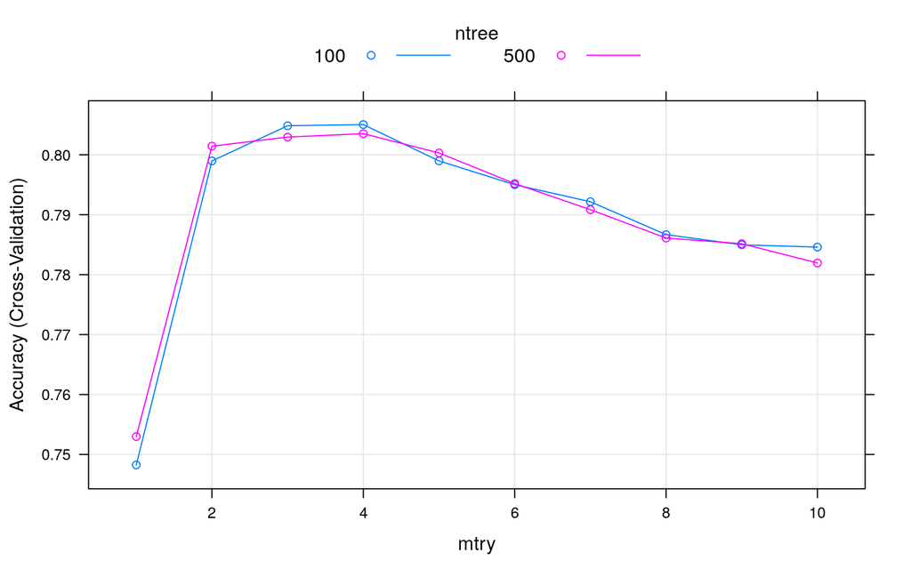

```r
plot(custom)
```

```r
results <- custom$results
param_opt <- results[which.max(results$Accuracy), c(1,2)]
```

A simple vista, la mejor combinación de parámetros es mtry = 4 y ntree = 100. Volvemos a entrenar nuestro algoritmo de Random Forest con la mejor combinación resultante.

```r
train_fit <- randomForest(Churn~., data=df_train_factor,
                          ntree = param_opt[,"ntree"],
                          mtry = param_opt[,"mtry"])
```

-Prediccion en Test:

```r
predict_rf <- predict(train_fit, df_test_factor, type="prob")[,"class_1"]
```

El AUC que obtenemos es el siguiente:

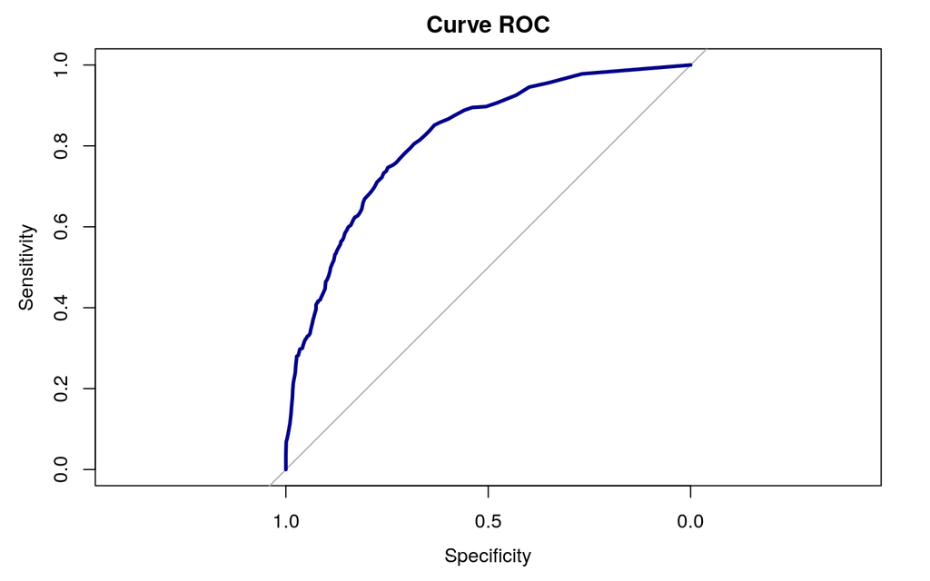

```r
roc_rf = roc(df_test_factor$Churn,as.vector(predict_rf))
plot(roc_rf,
     col="darkblue", lwd=3, main="Curve ROC")
```

```r
print(ModelMetrics::auc(df_test_factor$Churn,as.vector(predict_rf)))
```

```
[1] 0.8182229
```

```r
auc_df["rf", "auc"] = ModelMetrics::auc(df_test_factor$Churn, as.vector(predict_rf))
auc_df
```

```
            auc
glm   0.8448858
glm2  0.8448858
clust 0.8435591
knn   0.7029738
svm   0.8379476
tree  0.7872482
rf    0.8182229
```

### 3.5.8 Estrategia 8: Red Neuronal

Vamos a usar el paquete *neuralnet* por su simplicidad para resolver nuestro problema usando una red neuronal

```r
library(neuralnet)
require(nnet)
require(ggplot2)

df_train_nn <- df_train
df_test_nn <- df_test
df_train_nn$tenure.6 = df_backup_tenure[1:5283]
df_test_nn$tenure.6 = df_backup_tenure[5284:7043]

# Estadarizamos los predictores en el intervalo de 0 a 1
scl <- function(x){ (x - min(x))/(max(x) - min(x)) }
scaled_train <- data.frame(lapply(df_train_nn[, 1:15], scl))
scaled_test <- data.frame(lapply(df_test_nn[, 1:15], scl))

# Codificamos la variable respuesta con labels mediante la función del paquete nnet class.ind obteniendo dos clases
scaled_train <- cbind(scaled_train[, 1:15], class.ind(as.factor(df_train_nn$Churn)))
scaled_test <- cbind(scaled_test[, 1:15], class.ind(as.factor(df_test_nn$Churn)))
names(scaled_train) <- c(names(scaled_train)[1:15],"class_0","class_1")
names(scaled_test) <- c(names(scaled_test)[1:15],"class_0","class_1")

# Por las propiedades y la limitación de neuralnet debemos pasar los predictores uno a uno, vamos a automatizarlo de la siguiente forma:
n <- names(scaled_train)
f <- as.formula(paste("class_0 + class_1 ~", paste(n[!n %in% c("class_0","class_1")], collapse = " + ")))

#Entrenamos la red
nn <- neuralnet(f,
                data=scaled_train,
                hidden=c(3,2),
                act.fct = "logistic",
                err.fct = "sse",
                linear.output = FALSE,
                lifesign = "minimal",
                threshold = 0.1,
                rep = 1
                )
plot(nn)

# Predicción en train:
pr.nn <- compute(nn, scaled_train[, 1:15])
pr.nn_ <- pr.nn$net.result
original_values <- max.col(scaled_train[, 16:17])
pr.nn_2 <- max.col(pr.nn_)
# Accuracy en train
mean(pr.nn_2 == original_values)
```

```
[1] 0.8163922
```

```r
#Predicción en test:
pr.nn.test <- compute(nn, scaled_test[, 1:15])
pr.nn.test_ <- pr.nn.test$net.result
original_values.test <- max.col(scaled_test[, 16:17])
pr.nn.test_2 <- max.col(pr.nn.test_)
# Accuracy en test
mean(pr.nn.test_2 == original_values.test)
```

```
[1] 0.7965909
```

- **Calculamos el AUC**

```
[1] 0.8374581
```

- **Representamos la curva ROC**

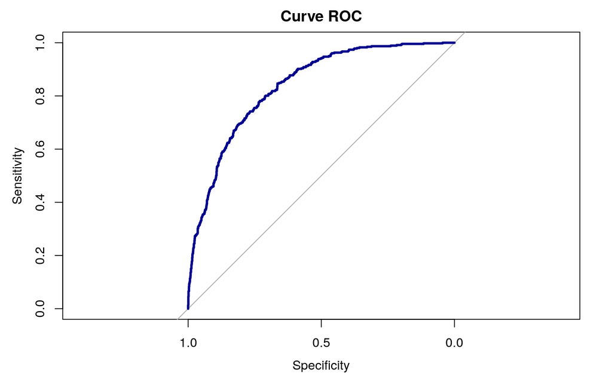

## 3.6 Balanceo muestral

Nuestro dataset dispone de un 26.7272383% de bajas. Balancearemos la muestra para que nuestros algoritmos puedan aprender mejor de las bajas de los clientes. Para ello, igualaremos la tasa de 0’s a la de 1’s, es decir, bajomuestrearemos al 50%.

```r
# bajomuestreamos al 50%
ratio_unos = 0.5

df_unos = df_train %>% filter(Churn== 1)
df_ceros = df_train %>% filter(Churn== 0)

dim_df_training = nrow(df_unos)/ratio_unos
dim_0s = dim_df_training - nrow(df_unos)
sample_0s = dim_0s/nrow(df_ceros)

zeros_under = sample_frac(df_ceros, sample_0s)

df_train = df_unos %>% bind_rows(zeros_under)

mean(df_train$Churn)
```

```
[1] 0.5
```

Ahora volvemos a aplicar la lgm con lasso:

- **Regresión lineal rebalanceando**

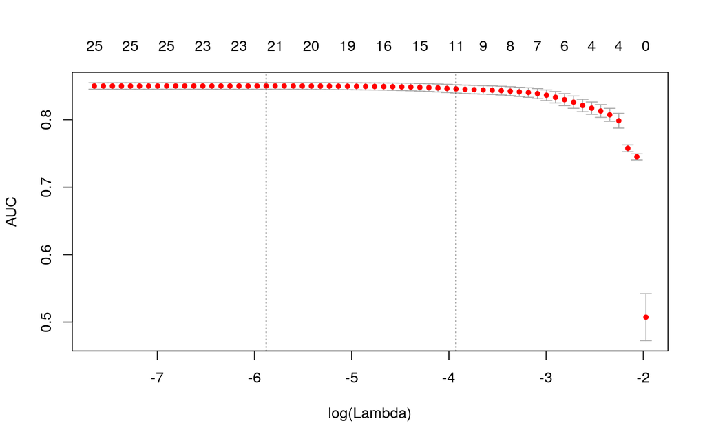

- Valor de lamba con el que entrenaremos:

```r
cv.out$lambda.1se
```

```
[1] 0.01971317
```

- Coeficientes del Lasso:

```r
tmp_coeffs <- coef(cv.out, s = "lambda.1se")

tmp_coeffs
```

```
28 x 1 sparse Matrix of class "dgCMatrix"
                                         1
(Intercept)                    0.392301900
gender                         .
SeniorCitizen                  0.128873472
Partner                        .
Dependents                     .
tenure.2                       .
tenure.3                       .
tenure.4                       .
tenure.5                       .
tenure.6                       .
MultipleLines.Nophoneservice   .
MultipleLines.Yes              .
InternetService.Fiberoptic     1.109723771
OnlineSecurity.Yes            -0.092447900
OnlineBackup.Yes               .
DeviceProtection.Yes           .
TechSupport.Yes                .
StreamingTV.Yes                0.051433033
StreamingMovies.Yes            0.008646682
Contract.Oneyear              -0.436253516
Contract.Twoyear              -0.922781291
PaperlessBilling               0.254122937
PaymentMethod.Creditcard       .
PaymentMethod.Electroniccheck  0.348756130
PaymentMethod.Mailedcheck      .
MonthlyCharges                 .
has_internet                   0.882335462
log_TotalCharges              -0.410764501
```

- **Predicción en Test**

```r
lasso.pred=predict(cv.out, newx = x_test, type="response")
```

- **Curva ROC y métrica AUC en Test**

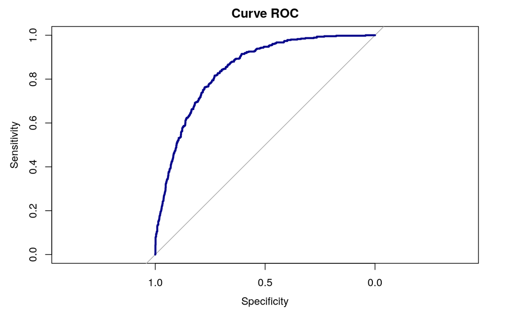

```
            auc
glm   0.8448858
glm2  0.8448858
clust 0.8435591
knn   0.7029738
svm   0.8379476
tree  0.7872482
rf    0.8182229
nn    0.8374581
glm3  0.8435575
```

- **Matriz de confusión**

```
Confusion Matrix and Statistics


lasso_class    0    1
          0 1211  275
          1   92  182

               Accuracy : 0.7915
                 95% CI : (0.7717, 0.8102)
    No Information Rate : 0.7403
    P-Value [Acc > NIR] : 3.24e-07

                  Kappa : 0.3766
 Mcnemar's Test P-Value : < 2.2e-16

            Sensitivity : 0.3982
            Specificity : 0.9294
         Pos Pred Value : 0.6642
         Neg Pred Value : 0.8149
             Prevalence : 0.2597
         Detection Rate : 0.1034
   Detection Prevalence : 0.1557
      Balanced Accuracy : 0.6638

       'Positive' Class : 1
```

## 3.7 Conclusiones

Otra métrica que pudo ser buena para afinar el modelo elegido hubiera sido recall o sensitividad (así se llama recall en problemas de clasificación binaria). Dicha métrica podría ser una buena opción dado que lo importante en los problemas de fuga de clientes de este tipo podía ser actuar urgentemente con campañas de marketing sobre los clientes que dejan la companía.

```
            auc
glm   0.8448858
glm2  0.8448858
clust 0.8435591
knn   0.7029738
svm   0.8379476
tree  0.7872482
rf    0.8182229
nn    0.8374581
glm3  0.8435575
```

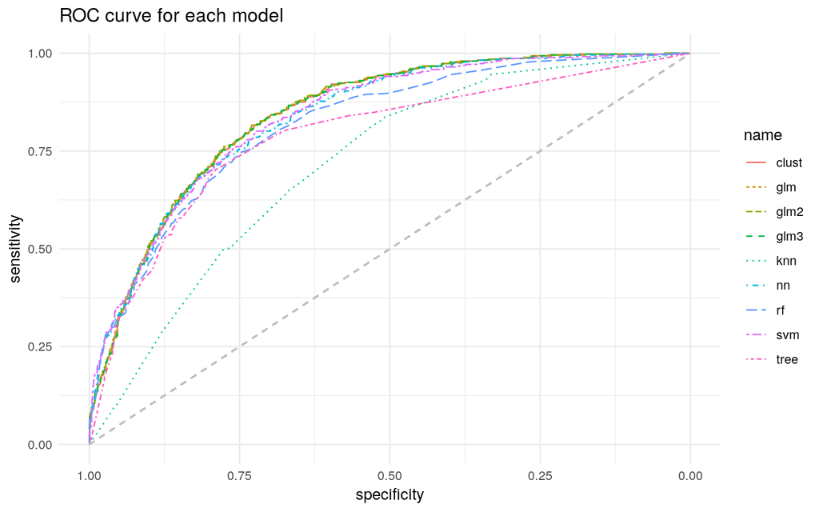

Javier Pérez, Marina Kurmanova y Lorena Rodriguez

2019-07-25